# Data Analysis: NYPD Shooting Incident (Historical)

G. Siegfried

August 8th, 2024

## Data Description

The data in the file is a list of shootings in NYC from 2006 to the end of 2023. It is extracted quarterly and then reviewed before being published to the NYC website. The data is comprised of information about the event, location and time of occurrence and the demographics of the suspect and victim. This data set can be found here: https://catalog.data.gov/dataset and is title “NYPD Shooting Incident Data (Historic)”.

More information about the data and its efficacy can be found here https://data.cityofnewyork.us/Public-Safety/NYPD-Shooting-Incident-Data-Historic-/833y-fsy8/about_data and footnotes about the data can be found in a pdf here https://data.cityofnewyork.us/api/views/833y-fsy8/files/e4e3d86c-348f-4a16-a17f-19480c089429?download=true&filename=NYPD_Shootings_Incident_Level_Data_Footnotes.pdf

### Required Packages

```r
# List of packages to check and load
packages <- c("ggplot2", "dplyr", "readr", "lubridate", "tidyr")
```

### Import Data:

The csv file for the historical NYPD Shooting Incident data can be found here:

```r
shooting_data <- read_csv("https://data.cityofnewyork.us/api/views/833y-fsy8/rows.csv?accessType=DOWNLOAD")
nrow(shooting_data)
```

```
## [1] 28562
```

```r
head(shooting_data,3)
```

```
## # A tibble: 3 × 21
##   INCIDENT_KEY OCCUR_DATE OCCUR_TIME BORO      LOC_OF_OCCUR_DESC PRECINCT
##          <dbl> <chr>      <time>     <chr>     <chr>                <dbl>
## 1    244608249 05/05/2022 00:10      MANHATTAN INSIDE                  14
## 2    247542571 07/04/2022 22:20      BRONX     OUTSIDE                 48
## 3     84967535 05/27/2012 19:35      QUEENS    <NA>                   103
## # ℹ 15 more variables: JURISDICTION_CODE <dbl>, LOC_CLASSFCTN_DESC <chr>,
## #   LOCATION_DESC <chr>, STATISTICAL_MURDER_FLAG <lgl>, PERP_AGE_GROUP <chr>,
## #   PERP_SEX <chr>, PERP_RACE <chr>, VIC_AGE_GROUP <chr>, VIC_SEX <chr>,
## #   VIC_RACE <chr>, X_COORD_CD <dbl>, Y_COORD_CD <dbl>, Latitude <dbl>,
## #   Longitude <dbl>, Lon_Lat <chr>
```

### Cleaning Data:

Removed Columns: JURISDICTION_CODE, LOC_OF_OCCUR_DESC, LOC_CLASSFCTN_DESC, LOCATION_DESC, PERP_AGE_GROUP, PERP_SEX, PERP_RACE, VIC_AGE_GROUP, VIC_SEX, VIC_RACE, X_COORD_CD, Y_COORD_CD, Latitude, Longitude, Lon_Lat

Columns were modified to present in the correct data type, and for the summary to utilize the values correctly.

```r
shooting_data <- shooting_data %>%
    select(1,2,3,4,6,10) %>%
    mutate(OCCUR_DATE = mdy(OCCUR_DATE))
nrow(shooting_data)
```

```
## [1] 28562
```

```r
head(shooting_data,3)
```

```
## # A tibble: 3 × 6
##   INCIDENT_KEY OCCUR_DATE OCCUR_TIME BORO      PRECINCT STATISTICAL_MURDER_FLAG
##          <dbl> <date>     <time>     <chr>        <dbl> <lgl>
## 1    244608249 2022-05-05 00:10      MANHATTAN       14 TRUE
## 2    247542571 2022-07-04 22:20      BRONX           48 TRUE
## 3     84967535 2012-05-27 19:35      QUEENS         103 FALSE
```

### Summary Data:

A data summary of the reduced column set and the modified date type for the OCCUR_DATE column.

```r
    summary(shooting_data)
```

```
##   INCIDENT_KEY         OCCUR_DATE          OCCUR_TIME           BORO
##  Min.   :  9953245   Min.   :2006-01-01   Length:28562      Length:28562
##  1st Qu.: 65439914   1st Qu.:2009-09-04   Class1:hms        Class :character
##  Median : 92711254   Median :2013-09-20   Class2:difftime   Mode  :character
##  Mean   :127405824   Mean   :2014-06-07   Mode  :numeric
##  3rd Qu.:203131993   3rd Qu.:2019-09-29
##  Max.   :279758069   Max.   :2023-12-29
##     PRECINCT     STATISTICAL_MURDER_FLAG
##  Min.   :  1.0   Mode :logical
##  1st Qu.: 44.0   FALSE:23036
##  Median : 67.0   TRUE :5526
##  Mean   : 65.5
##  3rd Qu.: 81.0
##  Max.   :123.0
```

```r
    nrow(shooting_data)
```

```
## [1] 28562
```

Missing Data - as can be seen, no rows are missing from the data. The only missing data comes from the removal of certain columns, whose value does not seem pertinent.

### Visualize Data:

#### General Plotting:

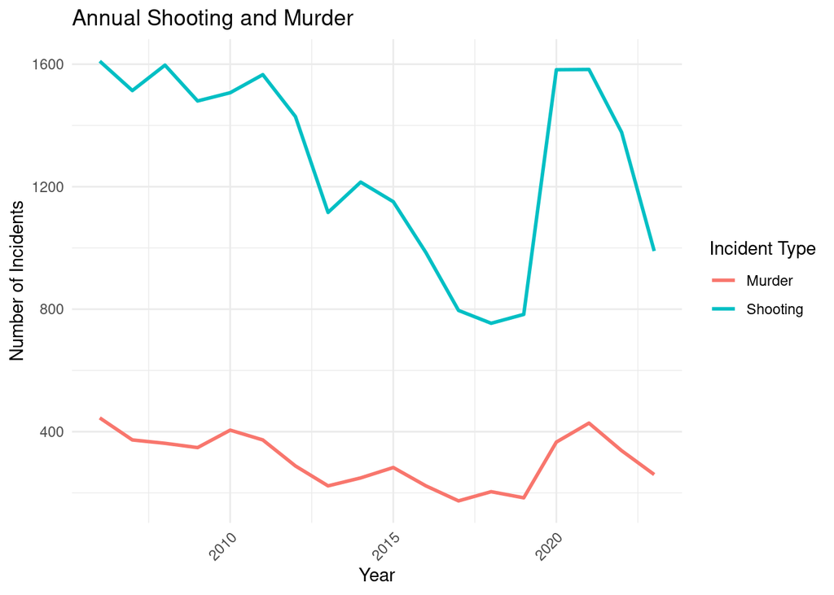

```r
# Aggregate incidents by date
shooting_data_clean <- shooting_data %>%
  mutate(OCCUR_DATE = as.Date(OCCUR_DATE, format = "%m/%d/%Y"), # Adjust format if necessary
         year = year(OCCUR_DATE)) %>% # Extract year
  group_by(BORO, year, STATISTICAL_MURDER_FLAG) %>% # Group by borough, year, and murder flag
  summarise(total_incidents = n(), .groups = 'drop') # Count incidents

shooting_data_summary <- shooting_data_clean %>%
  pivot_wider(names_from = STATISTICAL_MURDER_FLAG, values_from = total_incidents, values_fill = list(total_incidents = 0)) %>%
  rename(Shooting = `FALSE`, Murder = `TRUE`) # Rename for clarity

first_year <- min(shooting_data_summary$year) # Filter for oldest year
last_year <- max(shooting_data_summary$year) # Filter for last recent year

shooting_data_summary_year <- shooting_data_summary %>%
select(year, Shooting, Murder) %>%
group_by(year) %>%
summarise(Total_Shooting = sum(Shooting, na.rm = TRUE), Total_Murder = sum(Murder, na.rm = TRUE))

# Plot 1
ggplot(shooting_data_summary_year, aes(x = year)) +
  geom_line(aes(y = Total_Shooting, color = "Shooting"), linewidth = 1) +
  geom_line(aes(y = Total_Murder, color = "Murder"), linewidth = 1) +
  labs(title = "Annual Shooting and Murder",
       x = "Year",
       y = "Number of Incidents",
       color = "Incident Type") +
  theme_minimal() +
  theme(axis.text.x = element_text(angle = 45, hjust = 1))
```

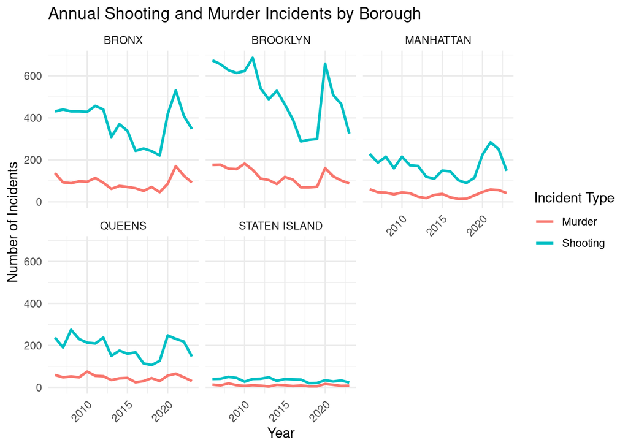

```r
# Plot 2
ggplot(shooting_data_summary, aes(x = year)) +
  geom_line(aes(y = Shooting, color = "Shooting"), linewidth = 1) +
  geom_line(aes(y = Murder, color = "Murder"), linewidth = 1) +
  facet_wrap(~ BORO) + # Create separate plots for each borough
  labs(title = "Annual Shooting and Murder Incidents by Borough",
       x = "Year",
       y = "Number of Incidents",
       color = "Incident Type") +
  theme_minimal() +
  theme(axis.text.x = element_text(angle = 45, hjust = 1)) # Rotate x-axis labels for readability
```

## Conclusion:

There are many sources of bias present within this analysis and data. The second set of graphs seem to illustrate some stark contrast bewteen boroughs. Going off the foot-notes from the NYPD pdf shared in the description, it could be possible for the lines between boroughs to be a little vague, or some circumstances like a shooting on a subway could be in one borough and end up in the next depending on the next destination location. Biases are also present as there is no population density or other measures that could help explain some of these numbers, especially in the break down of incidents between each borough. Finally, there are some biases on my part based on my ignorance of police procedures, the NYC area, and being somewhat green to statistical inferences.